# Parenting Observational Study E1

Emily & George

2020-03-27

Looking at the effect of electronically-delivered parenting interventions on parent-child interactions. Parents in the experimental condition viewed a video (designed for a parenting app) demonstrating an activity they could do with their child. Parents in the control condition did not view a video. Both groups of parents were asked to play with their child for 3 minutes with a set of props that matched the video demonstration they had seen. Children were 6-24 months of age. There were 6 videos total (2 per age group). Assignment to videos/sets of toys was counterbalanced within age groups. Parents also completed the Parenting Attitudes Questionnaire. Videos of the play sessions were coded for bids for joint attention, episodes of passive joint attention, and episodes of coordinated joint attention.

# 1 Data preprocessing

Preliminaries.

Read in files and consolidate to the same directory.

```r
# for rate coding (JA/minute), we coded the start / end of play sessions because they were not exactly 3 minutes
play_duration <- read.csv("parenting_obs_play_duration_E1.csv", header=T)
play_duration$start_sec = with(play_duration, ifelse(is.na(verbalcue_start_sec), # use verbal cue if it exists; otherwise play start
                                                           play_start_sec, verbalcue_start_sec))
play_duration <- play_duration %>%
  mutate(play_duration = play_stop_sec - start_sec)
sort(play_duration$play_duration) # shortest: 167 seconds
```

```
##  [1] 167 177 178 178 179 180 180 181 181 181 181 181 181 181 181 181 182 182 182
## [20] 183 183 183 184 184 184 184 185 185 187 188 188 189 189 190 191 192 193 196
## [39] 196 197 200 201 201 201 201 202 204 207 207 215 217 217 218 219 224 224 227
## [58] 240 247 258
```

```r
summary(play_duration$play_duration) # median = 201.5, mean=205.9
```

```
##    Min. 1st Qu.  Median    Mean 3rd Qu.    Max.
##   167.0   181.0   188.0   194.9   201.2   258.0
```

```r
# use play_duration$verbalcue_start_sec instead of play_start? (when it exists)


combine_datavyu_files <- function(data_dir) {
  d.long <- data.frame()
  files <- dir(data_dir)

  for (f in files) {
    jf <- paste(data_dir, f, sep="")
    jd <- read.csv(jf)

    # (assumes something happened early in the vid and late in the vid..)
    #vid_duration = jd[nrow(jd),]$JointAttention.offset - jd[1,]$JointAttention.onset
    #if(vid_duration < 180000) print(paste(f, "final - first coded time is less than 180 s:",vid_duration))
    SID = str_replace(f, ".csv", "")
    vid_duration = play_duration[which(play_duration$SID==SID),]$play_duration

    jd$phase_length = jd$JointAttention.offset - jd$JointAttention.onset
    if(length(which(jd$phase_length < 0))!=0) print(paste(f, "episode with negative duration!"))

    id <- data.frame(SID = SID, # "012017_01_recode"
                   line = jd$JointAttention.ordinal, # numbered list of episodes e.g. 0 1 2 3 4 5 6 7
                   phase_length = jd$phase_length,
                   pja = jd$JointAttention.pJA, # was episode passive?
                   cja = jd$JointAttention.cJA,
                   bid = jd$JointAttention.bids, # parent bids (1=parent, 0=kid)
                   vid_duration = vid_duration
                )

    d.long <- rbind(d.long, id)
    #d.raw <- bind_rows(d.raw, sd)
  }
  return(d.long)
}

d.long <- combine_datavyu_files("data/")
```

```
## [1] "092216_04.csv episode with negative duration!"
## [1] "120916_05.csv episode with negative duration!"
```

```r
d.long[which(d.long$phase_length<0),] # 3, but only bids so duration doesn't matter
```

```
##           SID line phase_length pja cja bid vid_duration
## 367 092216_04    9      -179515   0   0   1          190
## 692 120916_05   12      -181322   0   0   1          180
## 693 120916_05   13      -183877   0   0   1          180
```

```r
dim(d.long %>% filter((cja==1 | pja==1) & phase_length<3000)) # 150
```

```
## [1] 12  7
```

```r
d.long[which(d.long$phase_length<3000),c("cja","pja")] = 0 # any episodes <3s not counted (except bids)

d.long[which(rowSums(d.long[,c("pja","cja","bid")])==0),] # now several rows are not even classified as bids - should elim
```

```
##           SID line phase_length pja cja bid vid_duration
## 61  012017_06    3         2878   0   0   0          184
## 118 042416_02    3         2611   0   0   0          217
## 240 052317_03   15         2752   0   0   0          181
## 320 091316_05    0         2749   0   0   0          183
## 463 101416_09    9         2761   0   0   0          181
## 488 110416_03    5         2943   0   0   0          207
## 534 111716_01    5         2017   0   0   0          193
## 590 111716_07   12         2606   0   0   0          181
## 599 111716_08    2         2887   0   0   0          181
## 619 120416_01   11         2811   0   0   0          177
## 732 121516_03    1         2604   0   0   0          188
## 739 121516_04    1         2697   0   0   0          204
```

```r
# summarise per subject
# Emily only coded unsuccessful parent bids in Exp 1, assuming that any cJA episode started with a parent bid
d.raw <- d.long %>% group_by(SID) %>%
  mutate(vid_duration = vid_duration / 60, # seconds to minutes
         phase_length = phase_length / 1000) %>% # ms to seconds
  summarise(bids=sum(bid) + sum(cja), pja_length=sum(pja*phase_length), cja_length=sum(cja*phase_length),
            pja=sum(pja), cja=sum(cja), vid_duration=vid_duration[1]) %>%
  mutate(total_ja = pja + cja, total_lja = pja_length + cja_length)

# normalize to rates (e.g., bids/minute and seconds / min duration of JA)
vid_dur = d.raw$vid_duration
d.raw[,2:9] = d.raw[,2:9] / d.raw$vid_duration
d.raw$vid_duration = vid_dur
```

Read in trial info and demographics.

```r
conditions <- read.csv("conditions.csv")

load("../paq/paq_demo.RData")
load("../paq/obs_demo.RData")

ids <- ids%>%
  mutate(SID = sid)%>%
  select(-sid)

demo <- demo%>%
  mutate(SID = sid)%>%
  select(-sid)%>%
  mutate(age_months = age * 12)

demo$age_group[demo$age_months < 12] <- "6"
demo$age_group[demo$age_months >= 12 & demo$age_months < 18 ] <- "12"
demo$age_group[demo$age_months >= 18] <- "18"

#note from Emily- I calculated total bids by adding unsuccessful bids + episodes of joint attention that were acheived. In retrospect, this assumes that all episodes of JA were initiated by parent, which is probably false. Next time, code all parent bids rather than only unsuccessful ones.
d <- d.raw %>%
  left_join(conditions)%>%
  mutate(bids_tot = bids + cja + pja)%>%
  left_join(demo)%>%
  left_join(ids)%>%
  select(-sid)
```

# 2 Demographics

```r
demos <- conditions%>%
  left_join(demo)

demos$parent_ed[demos$parent_ed == 1] <- 8
demos$parent_ed[demos$parent_ed == 2] <- 12
demos$parent_ed[demos$parent_ed == 3] <- 14
demos$parent_ed[demos$parent_ed == 4] <- 18
demos$parent_ed[demos$parent_ed == 5] <- 20
demos$parent_ed[demos$parent_ed == 6] <- 22

#child gender
table(demos$Condition, demos$gender)
```

```
##
##           F  M
##   con  0 20 10
##   exp  0 22  8
```

```r
#ethnicity
table(demos$Condition, demos$ethnicity)
```

```
##
##          asian asian/white black/ white/ other black/african american
##   con  1     4           4                   0                      1
##   exp  3     7           5                   1                      0
##
##       Black/african american black/african american/white black/white decline
##   con                      1                            0           0       1
##   exp                      0                            0           0       0
##
##       hispanic mexican american mexican/portuguese middle eastern other white
##   con        1                1                  1              0     1    13
##   exp        0                0                  0              1     1    12
##
##       white/asian white/asian/pacific islander white/filipino white/hispanic
##   con           0                            0              1              0
##   exp           0                            0              0              0
##
##       white/mexican
##   con             0
##   exp             0
```

```r
#years of education
table(demos$Condition, demos$parent_ed)
```

```
##
##       12 14 18 20 22
##   con  4  3 12  2  9
##   exp  1  4  4  0 21
```

# 3 Reliability

Import reliability coder’s data (20 participants were coded for reliability).

```r
d.long_rel <- combine_datavyu_files("rel_data/")

d.long_rel[which(d.long_rel$phase_length<0),]
```

```
## [1] SID          line         phase_length pja          cja
## [6] bid          vid_duration
## <0 rows> (or 0-length row.names)
```

```r
# SID=120916_03  line=7  -1275   0  1    1   - cja + bid, so should double-check

dim(d.long_rel %>% filter((cja==1 | pja==1) & phase_length<3000)) # 39
```

```
## [1] 1 7
```

```r
d.long_rel[which(d.long_rel$phase_length<3000),c("cja","pja")] = 0 # any episodes <3s not counted (except bids)

# summarise per subject
d.raw_rel <- d.long_rel %>% group_by(SID) %>%
  mutate(vid_duration = vid_duration / 60, # seconds to minutes
         phase_length = phase_length / 1000) %>% # ms to seconds
  summarise(bids=sum(bid) + sum(cja), pja_length=sum(pja*phase_length), cja_length=sum(cja*phase_length),
            pja=sum(pja), cja=sum(cja), vid_duration=vid_duration[1]) %>%
  mutate(total_ja = pja + cja, total_lja = pja_length + cja_length)

# normalize to rates (e.g., bids/minute)
d.raw_rel[,2:9] = d.raw_rel[,2:9] / d.raw_rel$vid_duration
```

## 3.1 Check Reliability

```r
d.raw_rel <- d.raw_rel %>%
  mutate(bids_rel = bids, pja_rel = pja, cja_rel = cja, l_pja_rel = pja_length, l_cja_rel = cja_length) %>%
  select(SID, bids_rel, pja_rel, cja_rel, l_cja_rel, l_pja_rel)

d.raw %>% summarise(bids = mean(bids), cja=mean(cja), pja=mean(pja), l_pja=mean(pja_length), l_cja=mean(cja_length))
```

[output not shown]

```r
d.raw <- d.raw %>% mutate(l_pja = pja_length, l_cja = cja_length)

d_rel <- d.raw_rel %>% left_join(d.raw, by="SID") %>%
  select(SID, bids, bids_rel, pja, pja_rel, cja, cja_rel, l_cja, l_cja_rel, l_pja, l_pja_rel)


get_ICC2 <- function(dat)  {
  rel = psych::ICC(dat, missing = FALSE, alpha = 0.05)
  return(rel$results[2,])
}

bids_rel = get_ICC2(d_rel[,c("bids","bids_rel")]) # .79 [.55, .91]

pja_rel = get_ICC2(d_rel[,c("pja","pja_rel")]) # eps pass JA .34 [-.11, .67]

cja_rel = get_ICC2(d_rel[,c("cja","cja_rel")]) # eps coord JA .66 [.32, .85]

l_pja_rel = get_ICC2(d_rel[,c("l_pja","l_pja_rel")]) # pass JA length .33 [-.11, .67]

l_cja_rel = get_ICC2(d_rel[,c("l_cja","l_cja_rel")]) # coord JA length .60 [.24, .82]

save(d, file="Exp1_joint_attention_data.RData")
```

Inter-rater reliability is very high for number of bids, high for number of episodes of coordinated joint attention, but there is less agreement for episodes passive joint attention.

# 4 Plots

Total parent bids (successful and unsuccessful) per minute.

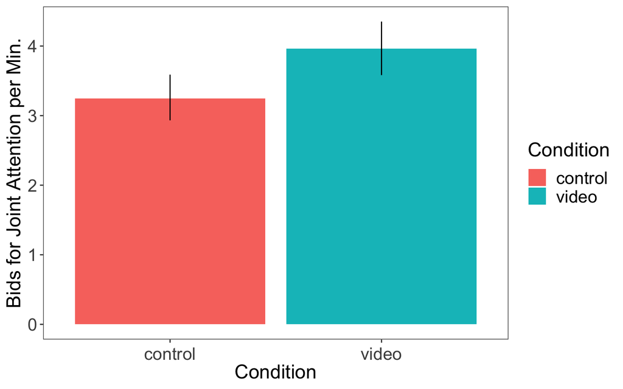

Total episodes of joint attention.

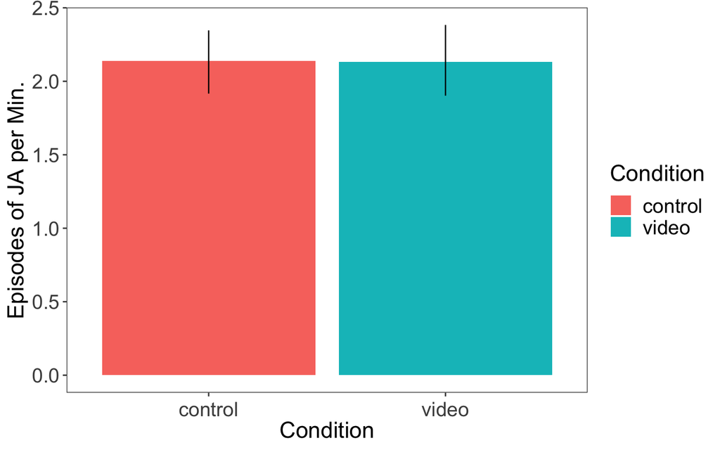

Episodes of passive joint attention.

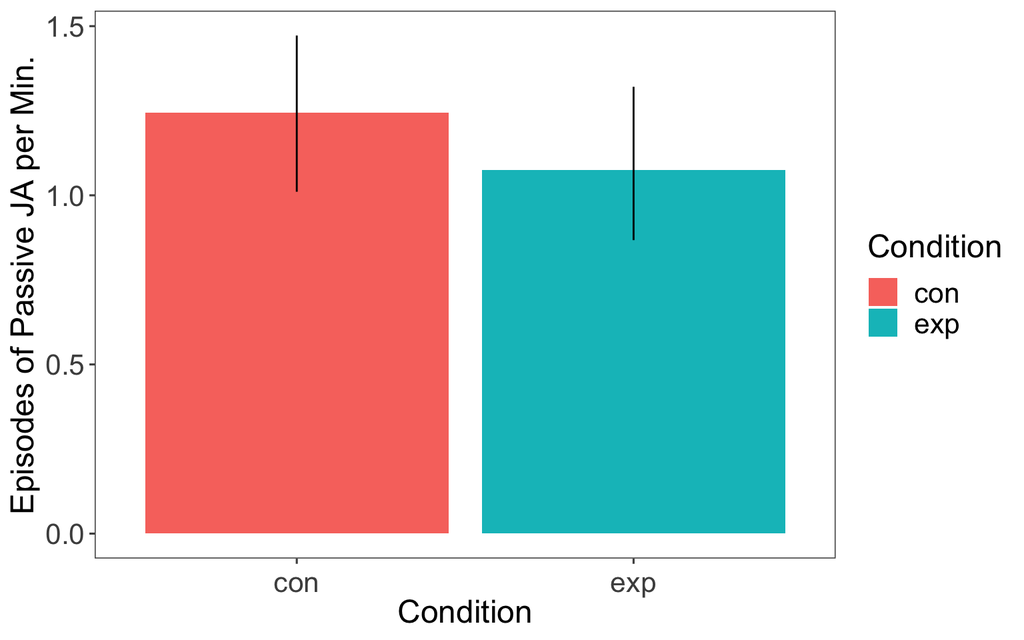

Episodes of coordinated joint attention

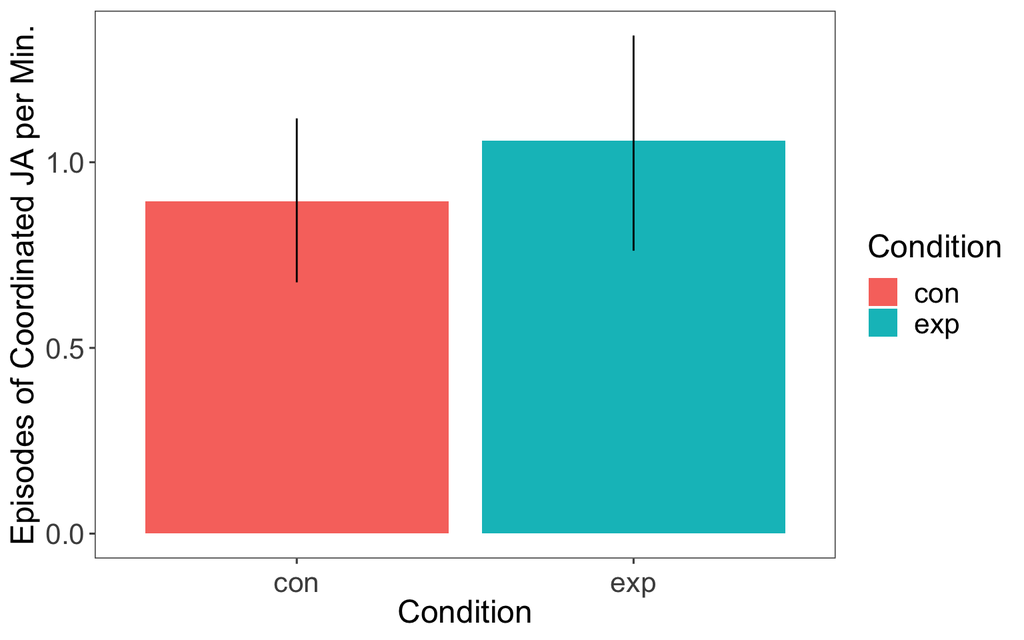

Total duration of passive joint attention.

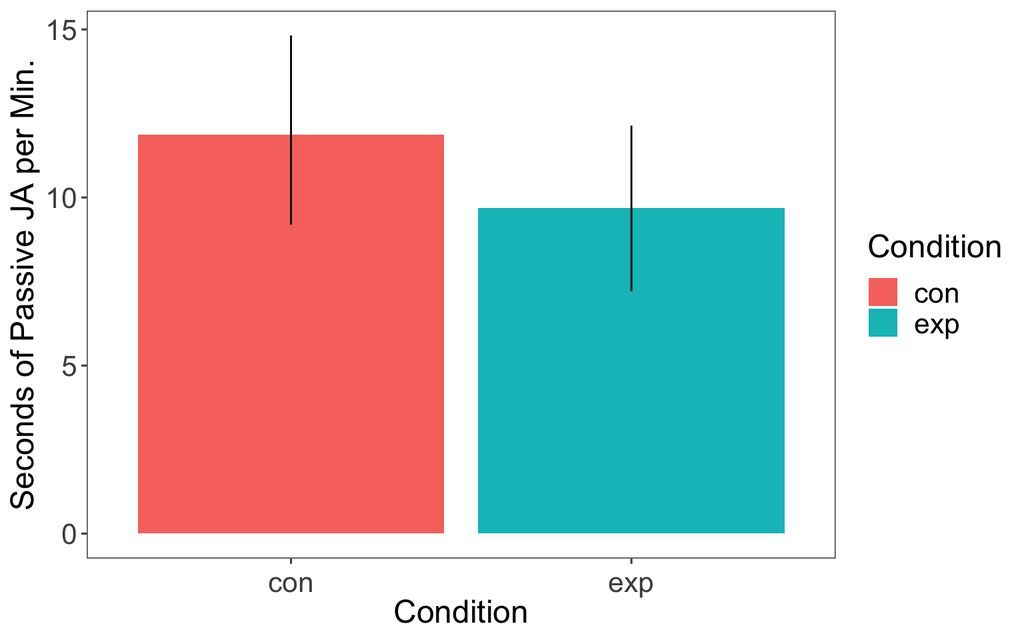

Total duration of coordinated joint attention.

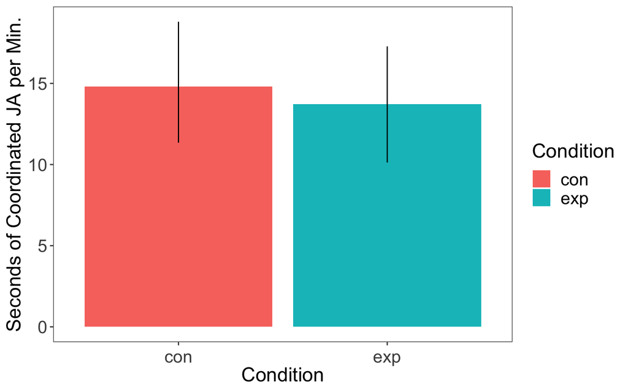

## 4.1 Demographics

### 4.1.1 Child gender

Total bids by gender.

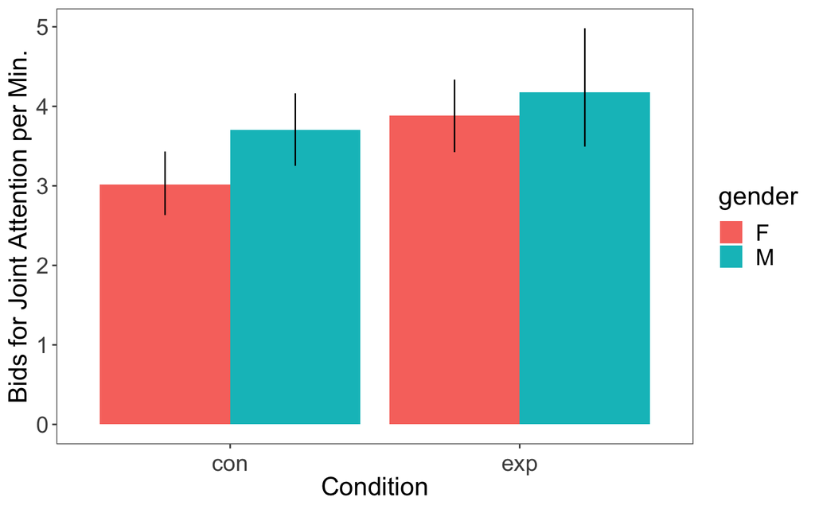

Total duration of passive joint attention by gender

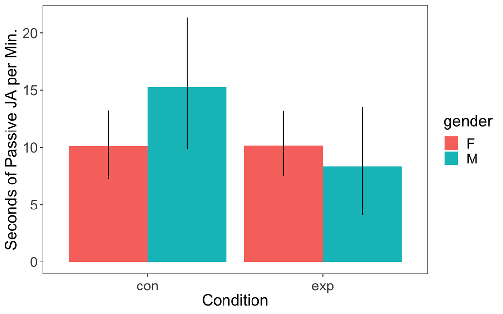

Total duration of coordinated joint attention by gender

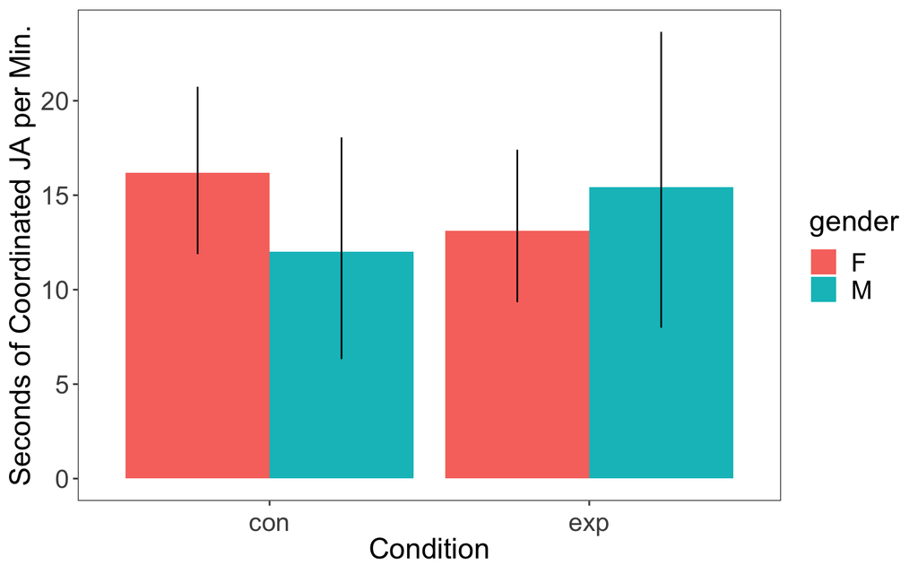

### 4.1.2 Child age

Children were separated into 3 age groups: 6-12 months, 12-18 months, and 18-24 months.

Total bids by age.

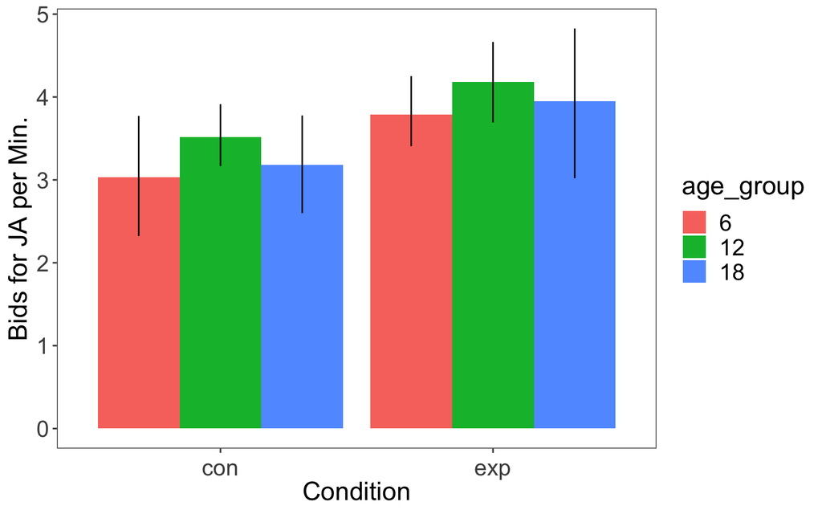

Total duration of passive joint attention by age

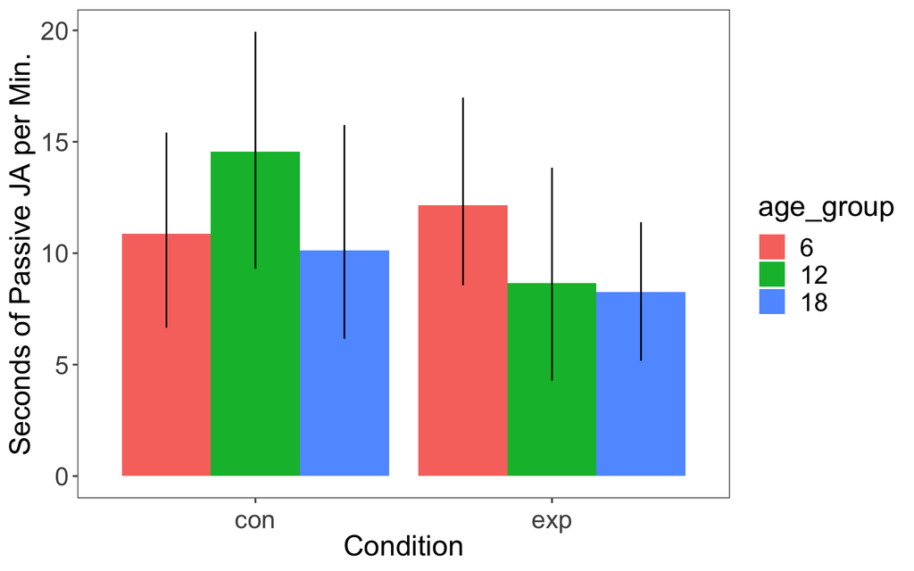

Total duration of coordinated joint attention by age

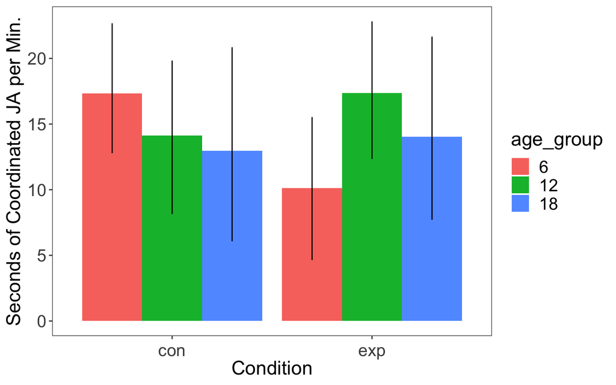

### 4.1.3 Parenting attitudes and education

Do PAQ scores predict the number of bids for joint attention by parents?

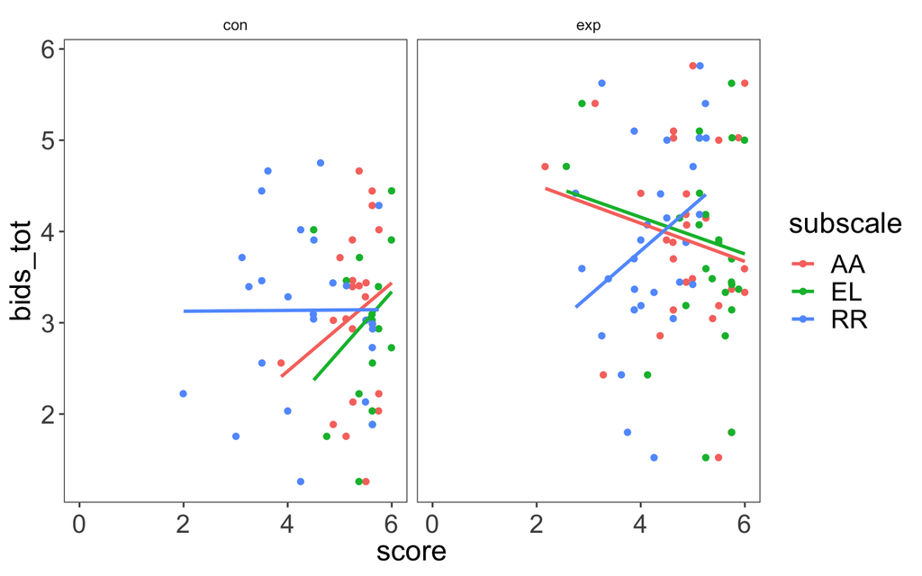

Does parent education predict the number of bids for joint attention by parents?

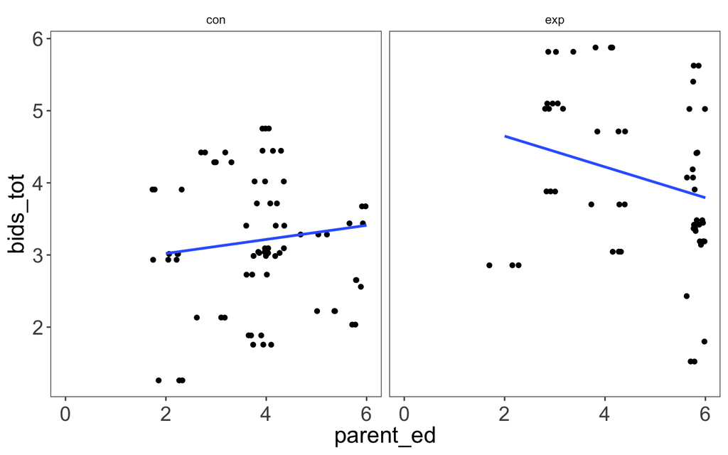

# 5 Analysis

Is the duration of joint attention correlated with age in months?

```r
cormat <- d %>%
  select(age_months, pja_length, cja_length, total_lja)
rcorr(as.matrix(cormat))
```

```
##            age_months pja_length cja_length total_lja
## age_months       1.00      -0.17      -0.02     -0.16
## pja_length      -0.17       1.00      -0.50      0.26
## cja_length      -0.02      -0.50       1.00      0.71
## total_lja       -0.16       0.26       0.71      1.00
##
## n= 60
##
##
## P
##            age_months pja_length cja_length total_lja
## age_months            0.2030     0.8560     0.2136
## pja_length 0.2030                0.0000     0.0454
## cja_length 0.8560     0.0000                0.0000
## total_lja  0.2136     0.0454     0.0000
```

## 5.1 Mixed effects models.

Prepare data.

```r
lmer_data <- d %>%
  filter(!is.na(AA), !is.na(EL), !is.na(RR))%>%
  mutate(Condition = factor(Condition),
         bids_tot = as.numeric(bids_tot),
         EL = as.numeric(langcog::scale(EL, scale=FALSE)),
         AA = as.numeric(langcog::scale(AA, scale=FALSE)),
         RR = as.numeric(langcog::scale(RR, scale=FALSE)),
         age = as.numeric(langcog::scale(age, scale=FALSE)),
         gender = as.factor(gender),
         Video = as.factor(Video))
```

Total number of bids

```r
maximal_mod <- lmer(bids_tot ~ Condition *  EL  + Condition * AA + Condition * RR + age + gender + parent_ed +
                           (1| Video), data = lmer_data)
summary(maximal_mod)
```

```
## Linear mixed model fit by REML. t-tests use Satterthwaite's method [
## lmerModLmerTest]
## Formula: bids_tot ~ Condition * EL + Condition * AA + Condition * RR +
##     age + gender + parent_ed + (1 | Video)
##    Data: lmer_data
##
## REML criterion at convergence: 147.9
##
## Scaled residuals:
##      Min       1Q   Median       3Q      Max
## -1.99276 -0.70413  0.03158  0.47015  1.97579
##
## Random effects:
##  Groups   Name        Variance Std.Dev.
##  Video    (Intercept) 0.04201  0.2050
##  Residual             0.90392  0.9507
## Number of obs: 54, groups:  Video, 6
##
## Fixed effects:
##                 Estimate Std. Error       df t value Pr(>|t|)
## (Intercept)      3.05589    0.57778 31.65933   5.289 8.83e-06 ***
## Conditionexp     1.11270    0.32604 40.29661   3.413  0.00148 **
## EL               0.70684    0.54745 42.65948   1.291  0.20360
## AA               0.57926    0.44998 42.99708   1.287  0.20487
## RR              -0.11245    0.23098 41.53927  -0.487  0.62892
## age              0.02585    0.37983  6.12285   0.068  0.94791
## genderM          0.73828    0.31571 41.77688   2.338  0.02423 *
## parent_ed       -0.09440    0.12076 40.38418  -0.782  0.43893
## Conditionexp:EL -0.72184    0.67573 42.65960  -1.068  0.29142
## Conditionexp:AA -0.79698    0.57580 42.45714  -1.384  0.17355
## Conditionexp:RR  0.57435    0.33545 41.18012   1.712  0.09439 .
## ---
## Signif. codes:  0 '***' 0.001 '**' 0.01 '*' 0.05 '.' 0.1 ' ' 1
##
## Correlation of Fixed Effects:
##             (Intr) Cndtnx EL     AA     RR     age    gendrM prnt_d Cnd:EL
## Conditionxp  0.003
## EL          -0.027  0.360
## AA          -0.292  0.263 -0.096
## RR          -0.266 -0.234 -0.456  0.001
## age          0.130  0.050  0.141 -0.109 -0.020
## genderM     -0.098  0.047 -0.083  0.172  0.157 -0.149
## parent_ed   -0.879 -0.360 -0.148  0.102  0.339 -0.122 -0.083
## Condtnxp:EL -0.107 -0.323 -0.848  0.089  0.425 -0.155  0.079  0.265
## Condtnxp:AA  0.395 -0.115  0.122 -0.822 -0.078  0.166 -0.213 -0.252 -0.342
## Condtnxp:RR  0.063  0.178  0.287  0.023 -0.635 -0.044 -0.041 -0.113 -0.202
##             Cnd:AA
## Conditionxp
## EL
## AA
## RR
## age
## genderM
## parent_ed
## Condtnxp:EL
## Condtnxp:AA
## Condtnxp:RR  0.001
## convergence code: 0
## Model failed to converge with max|grad| = 0.00661731 (tol = 0.002, component 1)
```

Episodes of coordinated joint attention.

```r
maximal_mod <- lmer(cja ~ Condition *  EL  + Condition * AA + Condition * RR  + age + gender + parent_ed +
                           (1| Video), data = lmer_data)
summary(maximal_mod)
```

```
## Linear mixed model fit by REML. t-tests use Satterthwaite's method [
## lmerModLmerTest]
## Formula: cja ~ Condition * EL + Condition * AA + Condition * RR + age +
##     gender + parent_ed + (1 | Video)
##    Data: lmer_data
##
## REML criterion at convergence: 125.7
##
## Scaled residuals:
##      Min       1Q   Median       3Q      Max
## -1.79367 -0.57804  0.02658  0.56261  2.35760
##
## Random effects:
##  Groups   Name        Variance Std.Dev.
##  Video    (Intercept) 0.03121  0.1767
##  Residual             0.53619  0.7323
## Number of obs: 54, groups:  Video, 6
##
## Fixed effects:
##                 Estimate Std. Error       df t value Pr(>|t|)
## (Intercept)      0.36025    0.44882 32.99272   0.803    0.428
## Conditionexp     0.07130    0.25124 40.43103   0.284    0.778
## EL               0.04195    0.42252 42.60267   0.099    0.921
## AA              -0.13510    0.34761 42.99705  -0.389    0.699
## RR               0.20415    0.17811 41.54424   1.146    0.258
## age              0.28842    0.30029  6.66092   0.960    0.370
## genderM         -0.05213    0.24348 41.73766  -0.214    0.832
## parent_ed        0.12072    0.09350 41.12007   1.291    0.204
## Conditionexp:EL -0.10253    0.52238 42.83732  -0.196    0.845
## Conditionexp:AA  0.25923    0.44523 42.69428   0.582    0.563
## Conditionexp:RR -0.09390    0.25861 41.16617  -0.363    0.718
##
## Correlation of Fixed Effects:
##             (Intr) Cndtnx EL     AA     RR     age    gendrM prnt_d Cnd:EL
## Conditionxp  0.003
## EL          -0.027  0.361
## AA          -0.295  0.261 -0.096
## RR          -0.267 -0.234 -0.456  0.004
## age          0.126  0.043  0.129 -0.103 -0.015
## genderM     -0.094  0.047 -0.083  0.170  0.156 -0.143
## parent_ed   -0.878 -0.359 -0.148  0.107  0.341 -0.117 -0.085
## Condtnxp:EL -0.106 -0.324 -0.848  0.087  0.426 -0.144  0.078  0.264
## Condtnxp:AA  0.398 -0.113  0.123 -0.822 -0.081  0.161 -0.212 -0.257 -0.341
## Condtnxp:RR  0.064  0.179  0.288  0.021 -0.635 -0.045 -0.041 -0.113 -0.203
##             Cnd:AA
## Conditionxp
## EL
## AA
## RR
## age
## genderM
## parent_ed
## Condtnxp:EL
## Condtnxp:AA
## Condtnxp:RR  0.003
```

Episodes of passive joint attention.

```r
maximal_mod <- lmer(pja ~ Condition *  EL  + Condition * AA + Condition * RR  + age + gender + parent_ed +
                           (1| Video), data = lmer_data)
summary(maximal_mod)
```

```
## Linear mixed model fit by REML. t-tests use Satterthwaite's method [
## lmerModLmerTest]
## Formula: pja ~ Condition * EL + Condition * AA + Condition * RR + age +
##     gender + parent_ed + (1 | Video)
##    Data: lmer_data
##
## REML criterion at convergence: 117.7
##
## Scaled residuals:
##     Min      1Q  Median      3Q     Max
## -1.5025 -0.6966  0.1527  0.4518  2.3131
##
## Random effects:
##  Groups   Name        Variance Std.Dev.
##  Video    (Intercept) 0.03624  0.1904
##  Residual             0.43946  0.6629
## Number of obs: 54, groups:  Video, 6
##
## Fixed effects:
##                 Estimate Std. Error       df t value Pr(>|t|)
## (Intercept)      1.78555    0.41267 34.67075   4.327 0.000122 ***
## Conditionexp     0.05468    0.22768 40.57583   0.240 0.811425
## EL               0.25480    0.38395 42.50608   0.664 0.510519
## AA               0.18575    0.31636 42.94913   0.587 0.560183
## RR              -0.34323    0.16159 41.51506  -2.124 0.039661 *
## age             -0.10503    0.28537  7.42381  -0.368 0.723101
## genderM          0.32175    0.22094 41.64158   1.456 0.152821
## parent_ed       -0.16431    0.08542 42.00863  -1.923 0.061213 .
## Conditionexp:EL -0.28084    0.47598 42.98042  -0.590 0.558259
## Conditionexp:AA -0.20188    0.40585 42.92507  -0.497 0.621426
## Conditionexp:RR  0.59610    0.23451 41.09867   2.542 0.014891 *
## ---
## Signif. codes:  0 '***' 0.001 '**' 0.01 '*' 0.05 '.' 0.1 ' ' 1
##
## Correlation of Fixed Effects:
##             (Intr) Cndtnx EL     AA     RR     age    gendrM prnt_d Cnd:EL
## Conditionxp  0.004
## EL          -0.027  0.363
## AA          -0.300  0.258 -0.095
## RR          -0.270 -0.235 -0.457  0.008
## age          0.119  0.031  0.108 -0.093 -0.005
## genderM     -0.088  0.045 -0.083  0.168  0.154 -0.131
## parent_ed   -0.876 -0.357 -0.147  0.116  0.345 -0.107 -0.088
## Condtnxp:EL -0.104 -0.324 -0.849  0.085  0.426 -0.125  0.077  0.262
## Condtnxp:AA  0.403 -0.110  0.124 -0.823 -0.086  0.151 -0.209 -0.266 -0.338
## Condtnxp:RR  0.064  0.180  0.290  0.018 -0.634 -0.047 -0.040 -0.114 -0.204
##             Cnd:AA
## Conditionxp
## EL
## AA
## RR
## age
## genderM
## parent_ed
## Condtnxp:EL
## Condtnxp:AA
## Condtnxp:RR  0.006
```

Total duration of passive joint attention.

```r
maximal_mod <- lmer(pja_length ~ Condition *  EL  + Condition * AA + Condition * RR  + age + gender + parent_ed +
                           (1| Video), data = lmer_data)
summary(maximal_mod)
```

```
## Linear mixed model fit by REML. t-tests use Satterthwaite's method [
## lmerModLmerTest]
## Formula: pja_length ~ Condition * EL + Condition * AA + Condition * RR +
##     age + gender + parent_ed + (1 | Video)
##    Data: lmer_data
##
## REML criterion at convergence: 329
##
## Scaled residuals:
##      Min       1Q   Median       3Q      Max
## -1.23829 -0.74086 -0.08479  0.58182  2.39930
##
## Random effects:
##  Groups   Name        Variance Std.Dev.
##  Video    (Intercept)  6.158   2.482
##  Residual             59.338   7.703
## Number of obs: 54, groups:  Video, 6
##
## Fixed effects:
##                 Estimate Std. Error      df t value Pr(>|t|)
## (Intercept)      17.0554     4.8521 34.8815   3.515  0.00124 **
## Conditionexp     -0.4855     2.6477 40.3751  -0.183  0.85542
## EL               -0.3901     4.4740 42.3665  -0.087  0.93092
## AA                2.6083     3.6902 42.8646   0.707  0.48350
## RR               -1.9139     1.8806 41.2961  -1.018  0.31474
## age              -3.2530     3.4427  7.2437  -0.945  0.37515
## genderM           3.8400     2.5717 41.3861   1.493  0.14297
## parent_ed        -1.5440     0.9991 42.3891  -1.545  0.12970
## Conditionexp:EL  -1.9212     5.5566 42.9989  -0.346  0.73122
## Conditionexp:AA  -1.5463     4.7393 42.9922  -0.326  0.74580
## Conditionexp:RR   3.7539     2.7282 40.8026   1.376  0.17634
## ---
## Signif. codes:  0 '***' 0.001 '**' 0.01 '*' 0.05 '.' 0.1 ' ' 1
##
## Correlation of Fixed Effects:
##             (Intr) Cndtnx EL     AA     RR     age    gendrM prnt_d Cnd:EL
## Conditionxp  0.004
## EL          -0.027  0.364
## AA          -0.304  0.255 -0.095
## RR          -0.271 -0.236 -0.457  0.011
## age          0.114  0.021  0.092 -0.086  0.003
## genderM     -0.084  0.044 -0.082  0.167  0.153 -0.123
## parent_ed   -0.874 -0.355 -0.146  0.122  0.347 -0.100 -0.091
## Condtnxp:EL -0.103 -0.325 -0.849  0.083  0.427 -0.110  0.076  0.261
## Condtnxp:AA  0.406 -0.108  0.124 -0.824 -0.090  0.144 -0.208 -0.272 -0.336
## Condtnxp:RR  0.064  0.181  0.291  0.015 -0.634 -0.048 -0.039 -0.114 -0.205
##             Cnd:AA
## Conditionxp
## EL
## AA
## RR
## age
## genderM
## parent_ed
## Condtnxp:EL
## Condtnxp:AA
## Condtnxp:RR  0.009
```

Total duration of coordinated joint attention.

```r
maximal_mod <- lmer(cja_length ~ Condition *  EL  + Condition * AA + Condition * RR  + age + gender + parent_ed +
                           (1| Video), data = lmer_data)
summary(maximal_mod)
```

```
## Linear mixed model fit by REML. t-tests use Satterthwaite's method [
## lmerModLmerTest]
## Formula: cja_length ~ Condition * EL + Condition * AA + Condition * RR +
##     age + gender + parent_ed + (1 | Video)
##    Data: lmer_data
##
## REML criterion at convergence: 360
##
## Scaled residuals:
##      Min       1Q   Median       3Q      Max
## -1.47248 -0.67454 -0.01716  0.52293  2.16548
##
## Random effects:
##  Groups   Name        Variance Std.Dev.
##  Video    (Intercept)   0.0     0.00
##  Residual             128.8    11.35
## Number of obs: 54, groups:  Video, 6
##
## Fixed effects:
##                 Estimate Std. Error      df t value Pr(>|t|)
## (Intercept)       3.1520     6.5974 43.0000   0.478   0.6352
## Conditionexp     -2.6230     3.8824 43.0000  -0.676   0.5029
## EL                0.5780     6.4621 43.0000   0.089   0.9291
## AA                0.7953     5.2855 43.0000   0.150   0.8811
## RR                1.7234     2.7403 43.0000   0.629   0.5327
## age              -1.6496     3.9897 43.0000  -0.413   0.6813
## genderM          -2.9937     3.7416 43.0000  -0.800   0.4280
## parent_ed         2.7902     1.4000 43.0000   1.993   0.0526 .
## Conditionexp:EL  -0.4310     7.8976 43.0000  -0.055   0.9567
## Conditionexp:AA   0.8459     6.7240 43.0000   0.126   0.9005
## Conditionexp:RR   1.3215     3.9827 43.0000   0.332   0.7417
## ---
## Signif. codes:  0 '***' 0.001 '**' 0.01 '*' 0.05 '.' 0.1 ' ' 1
##
## Correlation of Fixed Effects:
##             (Intr) Cndtnx EL     AA     RR     age    gendrM prnt_d Cnd:EL
## Conditionxp  0.000
## EL          -0.027  0.356
## AA          -0.274  0.273 -0.098
## RR          -0.256 -0.231 -0.455 -0.011
## age          0.154  0.081  0.198 -0.137 -0.046
## genderM     -0.117  0.050 -0.085  0.179  0.162 -0.179
## parent_ed   -0.882 -0.368 -0.151  0.075  0.328 -0.153 -0.073
## Condtnxp:EL -0.112 -0.322 -0.846  0.098  0.424 -0.210  0.083  0.272
## Condtnxp:AA  0.378 -0.126  0.118 -0.820 -0.061  0.193 -0.221 -0.224 -0.348
## Condtnxp:RR  0.062  0.175  0.282  0.034 -0.638 -0.041 -0.045 -0.111 -0.198
##             Cnd:AA
## Conditionxp
## EL
## AA
## RR
## age
## genderM
## parent_ed
## Condtnxp:EL
## Condtnxp:AA
## Condtnxp:RR -0.011
## convergence code: 0
## boundary (singular) fit: see ?isSingular
```

# 6 Conclusions

There is a main effect of condition on total bids for joint attention. Parents in the experimental condition (i.e., those who saw a video demonstrating an activity) made a greater number of bids for joint attention with their child.

There was no effect of condition on the number of episodes of either passive or coordinated joint attention, or the duration of these episodes.

While the electronically-delivered parenting advice increased the number of bids for joint attention by parents, it did not significantly effect the number or duration of episodes of joint attention. One possibility is that child variables had a comparatively larger impact on the attainment of joint attention.